```r
library(tidyverse)
library(ggplot2)
library(cowplot)
library(moments)
```

Watch [Bunnies, Dragons and the ‘Normal’ World](https://www.nytimes.com/video/science/100000002452709/bunnies-dragons-and-the-normal-world.html) to refresh your knowledge of the Central limit theorem.

# Experiment

Load the file “data/loans_income.csv”, and convert it into a vector.

```r
loans_income <- read_csv("/Users/ozodbekadkhamov/DataspellProjects/sample-statistics1/data/loans_income.csv")
loans_income <- loans_income$x
```

Take a sample of 1000 values from `loans_income`, and make a histogram.

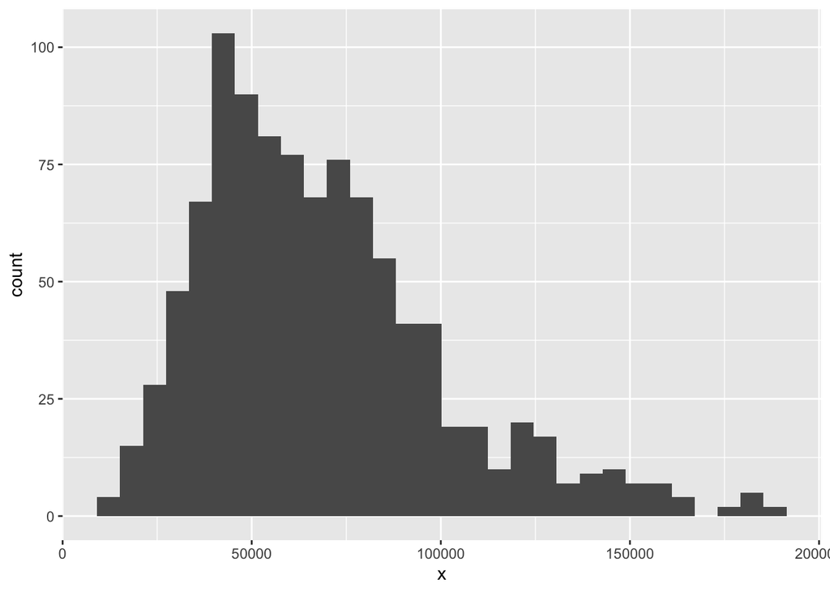

```r
simple_sample <- sample(loans_income, size=1000, replace=TRUE)

ggplot(data.frame(x=simple_sample)) +
  geom_histogram(aes(x=x), bins=30)
```

Take a sample of 5 values, calculate the mean. Repeat this procedure 1000 times.

```r
sample_by_5 <- replicate(1000, sample(loans_income, size=5))
sample_by_5 <- colMeans(sample_by_5)
```

Modify the function `sample_by()` so it can take samples not only by 5. Apply it to calculate sampling by 10 and 15.

```r
sample_by <- function(n) {
  x <- sample(loans_income, size=n)
  m <- mean(x)
  return(m)
}

sample_by_10 <- replicate(1000, sample_by(10))
sample_by_15 <- replicate(1000, sample_by(15))
```

We are going to make 4 histograms, one for each sample, but ggplot2 works only with data-frames, so we need to combine all vectors into one with `c()`, and then add labels to distinguish which value belongs to which sampling method.

```r
data <- data.frame(
  value = c(
    simple_sample,
    sample_by_5,
    sample_by_10,
    sample_by_15
  ),
  name = c(
    rep("simple", 1000),
    rep("by_5",  1000),
    rep("by_10", 1000),
    rep("by_15", 1000)
  )
)
```

Build histograms, mark them with different colors (fill).

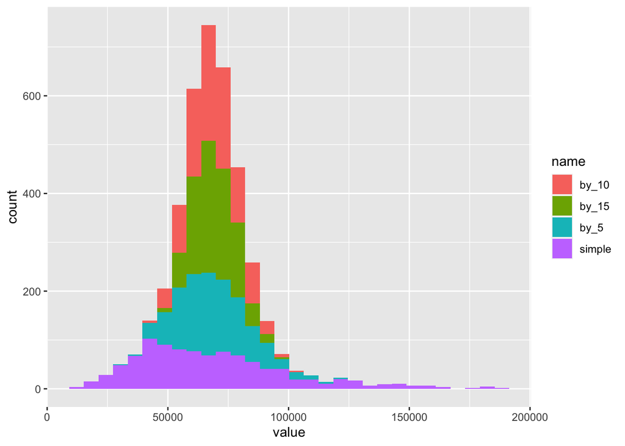

```r
p <- ggplot(data, aes(x=value, fill=name)) +
  geom_histogram(bins=30)

p
```

Separate this plot into 4 histograms.

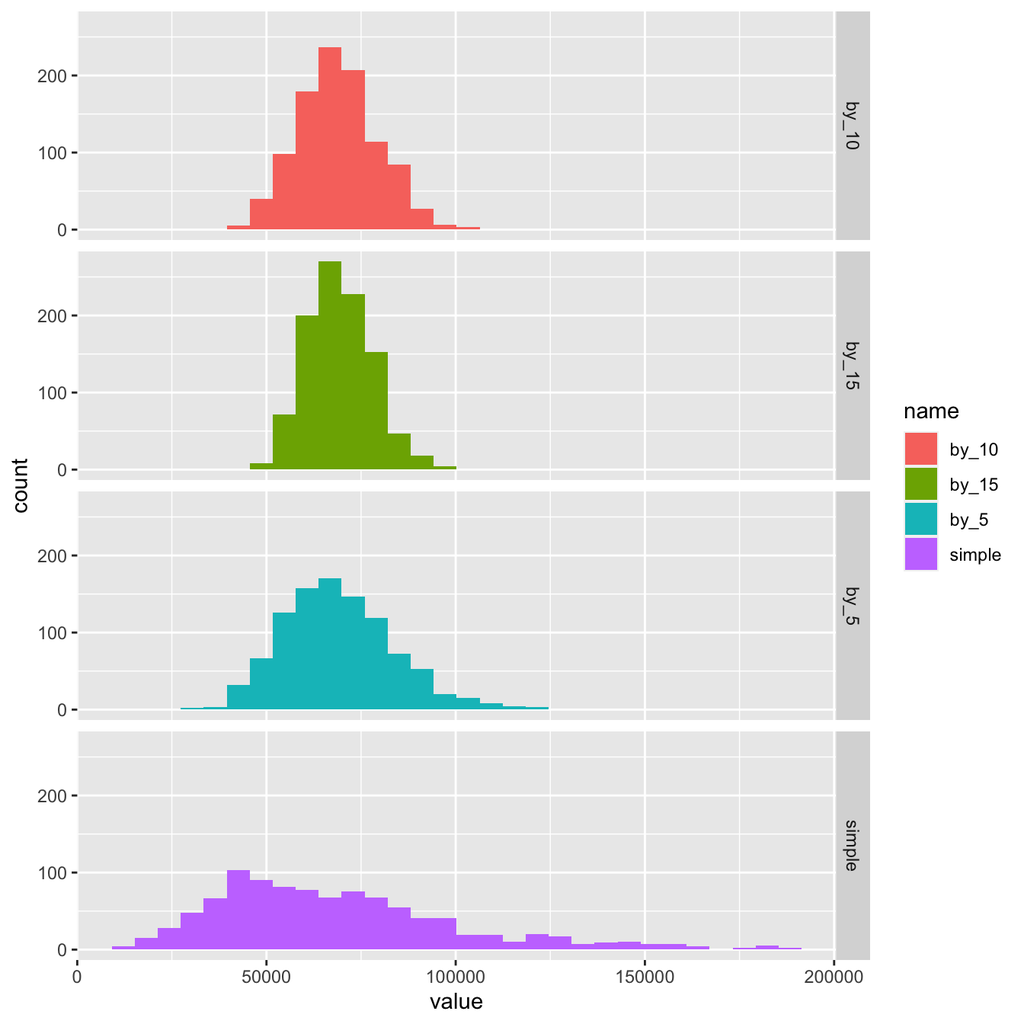

```r
p + facet_grid(rows=vars(name))
```

You can see, that ggplot2 put all histograms in a chaotic order. Is this placement random?

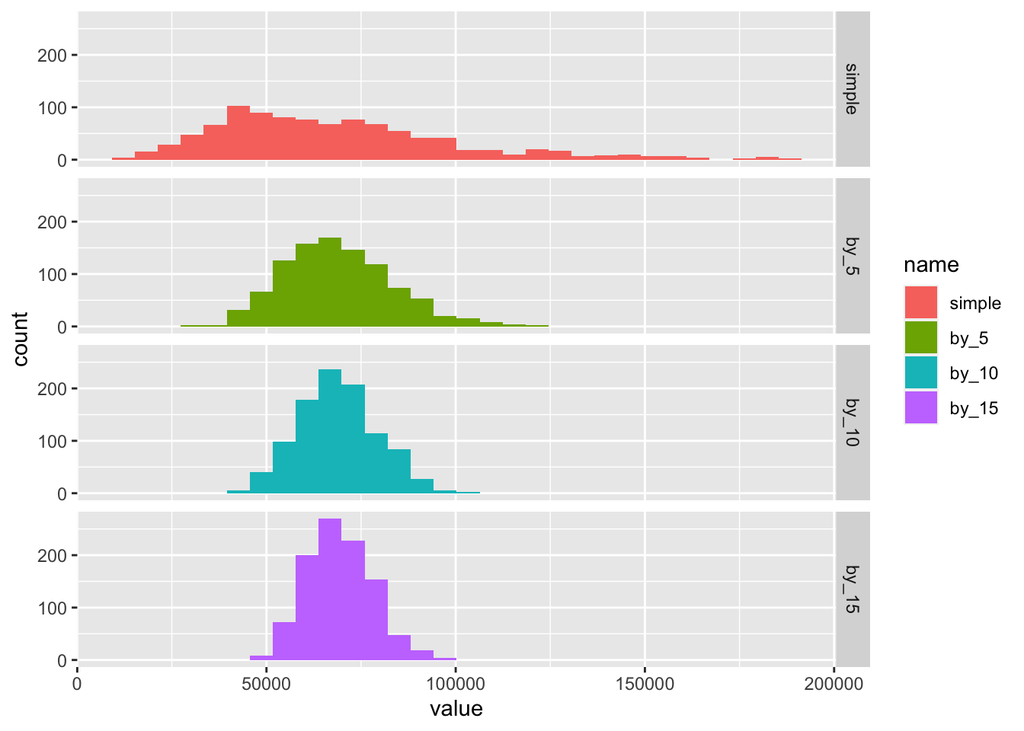

```r
data$name <- factor(data$name, levels=c("simple", "by_5", "by_10", "by_15"))

p <- ggplot(data, aes(x=value, fill=name)) +
  geom_histogram(bins=30) +
  facet_grid(rows=vars(name))

p
```

What do you think about the standard deviation of of the last 3 distributions? What distribution fits better to model them? May be exponential or binomial?

Add a vertical line to show the mean value of `loans_income`.

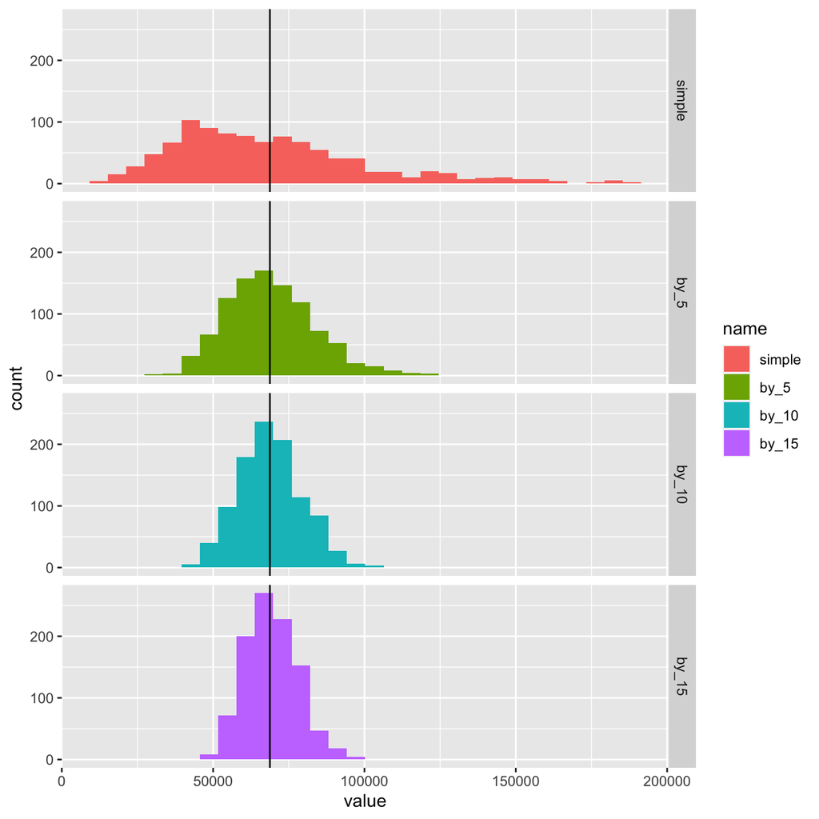

```r
p + geom_vline(xintercept=mean(loans_income))
```

# Central limit theorem

The phenomenon demonstrated in the plot above is termed the **central limit theorem**. It says that the means drawn from multiple samples will resemble the normal curve, even if the source population is not normally distributed, provided that the sample size is large enough and the departure of the data from normality is not too great.

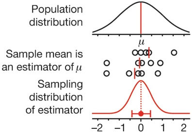

## Sample average

Calculate the arithmetic average for loans income and samples by 5, by 10, and by 15.

```r
mean(loans_income)
```

```
## [1] 68760.52
```

```r
mean(sample_by_5)
```

```
## [1] 69037.48
```

```r
mean(sample_by_10)
```

```
## [1] 68908.39
```

```r
mean(sample_by_15)
```

```
## [1] 69353.1
```

Check the skewness and kurtosis of the samples.

```r
library(moments)

cat("skewness\n")
```

```
## skewness
```

```r
skewness(sample_by_5)
```

```
## [1] 0.542002
```

```r
skewness(sample_by_10)
```

```
## [1] 0.244586
```

```r
skewness(sample_by_15)
```

```
## [1] 0.2994487
```

```r
cat("\nkurtosis\n")
```

```
##
## kurtosis
```

```r
kurtosis(sample_by_5)
```

```
## [1] 3.371405
```

```r
kurtosis(sample_by_10)
```

```
## [1] 2.855505
```

```r
kurtosis(sample_by_15)
```

```
## [1] 2.85236
```

## Standard error

**N.B.** Standard Error can also be called *Standard Deviation of Sample*.

Standard error of the sample average is calculated from the population’s SD:

$$SE(\bar{X}) = { \sigma \over \sqrt{n} }$$

Find the value of SE using this equation and compare it with the SD of the samples.

```r
cat("sample by 5:\n")
```

```
## sample by 5:
```

```r
sd(sample_by_5)
```

```
## [1] 14626.38
```

```r
sd(loans_income) / sqrt(5)
```

```
## [1] 14700.82
```

```r
cat("\nsample by 10:\n")
```

```
##
## sample by 10:
```

```r
sd(sample_by_10)
```

```
## [1] 10386.38
```

```r
sd(loans_income) / sqrt(10)
```

```
## [1] 10395.05
```

```r
cat("\nsample by 15:\n")
```

```
##
## sample by 15:
```

```r
sd(sample_by_15)
```

```
## [1] 8533.228
```

```r
sd(loans_income) / sqrt(15)
```

```
## [1] 8487.523
```

# How large sample?

Create a population as a random 10,000 values from the uniform distribution. Then using sampling by 2, 10, and 30, repeat the procedure from above to make 4 histograms.

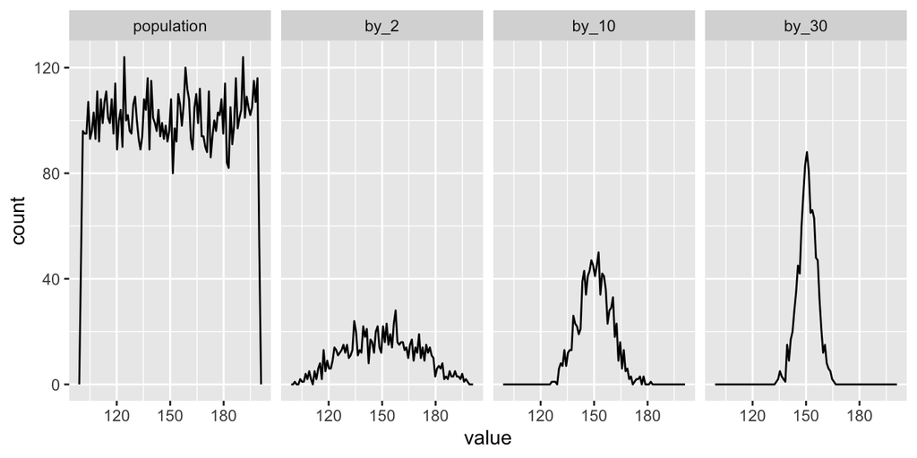

```r
population <- runif(10000, min=100, max=200)

sample_by <- function(n) {
  x <- sample(population, size=n)
  m <- mean(x)
  return(m)
}

data <- data.frame(
  by_2  = replicate(1000, sample_by(2)),
  by_10 = replicate(1000, sample_by(10)),
  by_30 = replicate(1000, sample_by(30))
)

data <- rbind(
  data.frame(name="population", value=population),
  pivot_longer(data, 1:3)
)

data$name <- factor(data$name, levels=c("population", "by_2", "by_10", "by_30"))

p1 <- ggplot(data, aes(x=value)) +
  geom_freqpoly(bins=100) +
  facet_grid(cols=vars(name), scales="free_y")

p1
```

Repeat for a bimodal distribution composed of two normal distribution with μ<sub>1</sub>=1 and μ<sub>2</sub>=2, σ=0.2.

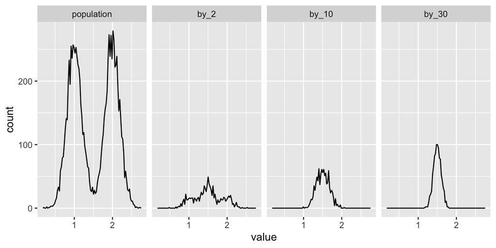

```r
population <- c(
  rnorm(5000, mean=1, sd=0.2),
  rnorm(5000, mean=2, sd=0.2)
)

data <- data.frame(
  by_2  = replicate(1000, sample_by(2)),
  by_10 = replicate(1000, sample_by(10)),
  by_30 = replicate(1000, sample_by(30))
)

data <- rbind(
  data.frame(name="population", value=population),
  pivot_longer(data, 1:3)
)

data$name <- factor(data$name, levels=c("population", "by_2", "by_10", "by_30"))

p2 <- ggplot(data, aes(x=value)) +
  geom_freqpoly(bins=100) +
  facet_grid(cols=vars(name), scales="free_y")

p2
```

Skewed distribution can be simulated with a Beta or Log-Normal distribution on your choice.

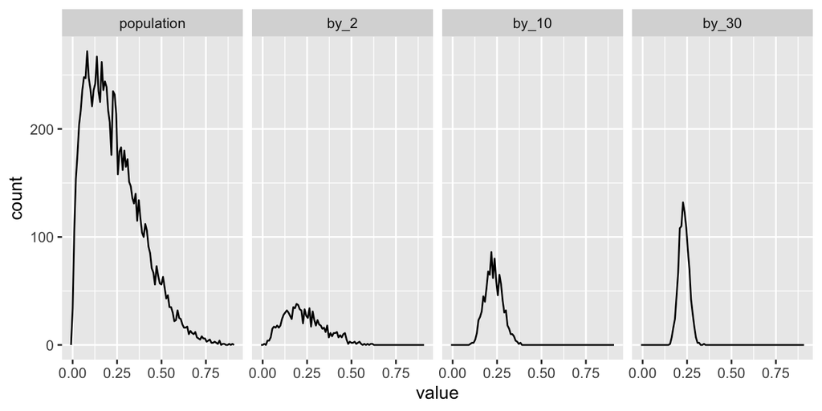

```r
population <- rbeta(10000, shape1=1.5, shape2=5)

data <- data.frame(
  by_2  = replicate(1000, sample_by(2)),
  by_10 = replicate(1000, sample_by(10)),
  by_30 = replicate(1000, sample_by(30))
)

data <- rbind(
  data.frame(name="population", value=population),
  pivot_longer(data, 1:3)
)

data$name <- factor(data$name, levels=c("population", "by_2", "by_10", "by_30"))

p3 <- ggplot(data, aes(x=value)) +
  geom_freqpoly(bins=100) +
  facet_grid(cols=vars(name), scales="free_y")

p3
```

**Conclusion:** The central limit theorem requires that n need to be big enough. In practice, when n is at least 30 the distribution of sample mean is approximately normal.

If the population is originally normally distributed then value of n is insignificant.

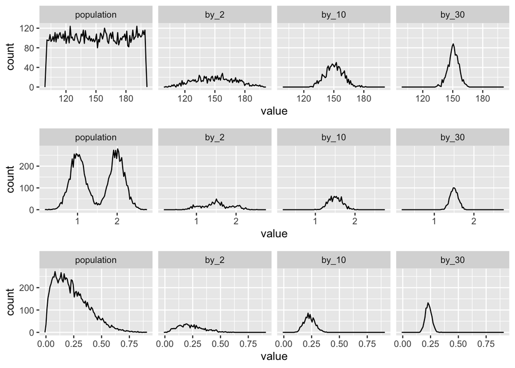

```r
plot_grid(p1, p2, p3, ncol=1)
```

Questions:

1. “A” has a right-skewed distribution, and we are calculating the sample mean from a random sample of 8 measurements. It is correct?
2. “B” has a left-skewed distribution, and we inference population statistics from a random sample of 50 measurements.
3. “C” has a normal distribution, and we are calculating the sample mean from a random sample of 3 measurements.